# BÁO CÁO CHI TIẾT ODICH_TCM_YEAR_2025

Author

Hoang Quoc Cuong

Published

April 23, 2026

# **ODICH_TCM 2025**

Báo cáo được cập nhập vào lúc **2026-04-23 16:58:51 | Dữ liệu ODICH_TCM 2025**

Bản đồ Cần Thơ (thông tin chi tiết phường, xã mới) [**click here**](https://tuhocr.github.io/canthosxh/MAP_CANTHO)

**Để copy file ảnh đồ thị full-size, ta right-click lên hình, chọn `Open image in new tab`**

# 1 **KIỂM TRA DỮ LIỆU**

**Nhập dữ liệu sai lệch năm (vd: file 2025 nhưng lại có bệnh nhân của năm 2026)**

**`Dữ liệu nhập lệch năm`**

```
Dữ liệu ban đầu: 199
Dữ liệu sau khi lọc theo năm: 197
Dữ liệu nhập lệch năm: 2
                  TTYTKV PHUONG_XA_MOI    NGAY_VV          HO   TEN TUOI NGUOI_NHAP_LIEU NGAY_NHAP_LIEU
108 TTYT KV TP Sóc Trăng      Mỹ Xuyên 2026-01-02    Danh Yến Hương  2.0     CDC Cần Thơ     2026-01-13
195      TTYT KV Vị Thủy    Vĩnh Tường 2026-01-01 Huỳnh Tuyết  Ngân  1.6     CDC Cần Thơ     2026-01-13
```

**Nếu tổng số `TTYTKV` không vượt quá 22 (năm 2025) hay 20 (năm 2026) thì dữ liệu chính xác.**

**Tổng số TTYTKV là 22**

**`TTYTKV`**

```
    TTYT KV Bình Thủy      TTYT KV Cái Răng  TTYT KV Châu Thành A TTYT KV Châu Thành HG TTYT KV Châu Thành ST   TTYT KV Cù Lao Dung
                    6                     3                     2                     9                     7                    23
      TTYT KV Kế Sách       TTYT KV Long Mỹ      TTYT KV Long Phú         TTYT KV Mỹ Tú      TTYT KV Mỹ Xuyên       TTYT KV Ngã Năm
                    6                     8                    12                    25                     8                     9
        TTYT KV Ô Môn    TTYT KV Phụng Hiệp     TTYT KV Thạnh Trị      TTYT KV Thới Lai      TTYT KV Thốt Nốt  TTYT KV TP Sóc Trăng
                    2                    22                     5                     3                     3                     7
      TTYT KV Trần Đề       TTYT KV Vị Thủy     TTYT KV Vĩnh Châu    TTYT KV Vĩnh Thạnh
                    8                    26                     1                     2
Tổng số TTYTKV là 22
```

**Nếu tổng số `PHUONG_XA_MOI` không vượt quá 103 thì dữ liệu chính xác.**

**Tổng số PHUONG_XA_MOI là 67**

**`PHUONG_XA_MOI`**

```
        An Ninh        An Thạnh         Cái Khế        Cái Răng      Châu Thành     Cù Lao Dung         Đại Hải        Đại Ngãi
              1              16               4               3               2               7               1               1
      Đại Thành      Đông Phước         Gia Hòa       Hiệp Hưng     Hồ Đắc Kiện          Hòa An         Hỏa Lựu          Hòa Tú
              2               2               4               4               2               4               4               1
        Kế Sách Lịch Hội Thượng         Liêu Tú       Long Hưng         Long Mỹ        Long Phú      Long Tuyền       Lương Tâm
              2               2               1               4               2               7               1               4
       Mỹ Hương        Mỹ Phước         Mỹ Quới           Mỹ Tú        Mỹ Xuyên         Ngã Bảy         Ngã Năm         Ngọc Tố
             15               2               5               4               1               2               2               3
        Nhơn Mỹ       Ninh Kiều           Ô Môn         Phú Hữu         Phú Lộc         Phú Lợi         Phú Tâm      Phụng Hiệp
              2               1               1               5               3               2               2               6
      Sóc Trăng         Tân Lộc        Tân Long  Tân Phước Hưng       Tân Thạnh       Thạnh Hòa   Thạnh Thới An      Thạnh Xuân
              4               1               2               2               3               2               1               2
    Thới An Hội       Thới Hưng        Thới Lai       Thới Long        Thốt Nốt       Thuận Hòa         Trần Đề      Trung Nhứt
              1               2               1               1               1               2               4               1
   Trường Khánh          Vị Tân        Vị Thanh      Vị Thanh 1         Vị Thủy        Vĩnh Lợi      Vĩnh Phước      Vĩnh Thạnh
              1               6               4               6               2               2               1               2
Vĩnh Thuận Đông      Vĩnh Tường        Xà Phiên
              2               2               2
Tổng số PHUONG_XA_MOI là 67
```

**Nếu kết quả tổng số ca theo `TTYTKV` và `PHUONG_XA_MOI` không vượt quá 103 thì dữ liệu chính xác.**

Số liệu này thể hiện bao nhiều phường xã có ca bệnh tương ứng với trung tâm y tế khu vực, tổng số không vượt qua 103 phường xã. Cần kiểm tra xem 1 phường xã có bị trùng ở các trung tâm y tế khu vực khác nhau không.

**Dữ liệu bị trùng**

```
        An Ninh        An Thạnh         Cái Khế        Cái Răng      Châu Thành     Cù Lao Dung         Đại Hải        Đại Ngãi
              1               1               1               1               1               1               1               1
      Đại Thành      Đông Phước         Gia Hòa       Hiệp Hưng     Hồ Đắc Kiện          Hòa An         Hỏa Lựu          Hòa Tú
              1               1               1               1               1               1               1               1
        Kế Sách Lịch Hội Thượng         Liêu Tú       Long Hưng         Long Mỹ        Long Phú      Long Tuyền       Lương Tâm
              1               1               1               1               1               1               1               1
       Mỹ Hương        Mỹ Phước         Mỹ Quới           Mỹ Tú        Mỹ Xuyên         Ngã Bảy         Ngã Năm         Ngọc Tố
              1               1               1               1               1               1               1               1
        Nhơn Mỹ       Ninh Kiều           Ô Môn         Phú Hữu         Phú Lộc         Phú Lợi         Phú Tâm      Phụng Hiệp
              1               1               1               1               1               1               1               1
      Sóc Trăng         Tân Lộc        Tân Long  Tân Phước Hưng       Tân Thạnh       Thạnh Hòa   Thạnh Thới An      Thạnh Xuân
              1               1               1               1               1               1               1               1
    Thới An Hội       Thới Hưng        Thới Lai       Thới Long        Thốt Nốt       Thuận Hòa         Trần Đề      Trung Nhứt
              1               1               1               1               1               1               1               1
   Trường Khánh          Vị Tân        Vị Thanh      Vị Thanh 1         Vị Thủy        Vĩnh Lợi      Vĩnh Phước      Vĩnh Thạnh
              1               1               1               1               1               1               1               1
Vĩnh Thuận Đông      Vĩnh Tường        Xà Phiên
              1               1               1
Tổng số PHUONG_XA_MOI là 67
[1] TTYTKV        PHUONG_XA_MOI TONG_SO_CA
<0 rows> (or 0-length row.names)
```

# 2 **SỐ** **Ổ DỊCH** **THEO NGÀY [DỮ LIỆU GỐC]**

[**Dữ liệu gốc ODICH_TCM_2025**](https://tuhocr.github.io/canthosxh/REPORT/ODICH_TCM_2025)

# 3 **TỔNG SỐ** **Ổ DỊCH** **TRONG NĂM THEO KHU VỰC**

**Từ ngày 2025-01-04 đến ngày 2025-12-28**

**Tổng số ổ dịch: 197 | Tổng số TTYT KV: 22 | Tổng số phường, xã: 103**

**Tổng số phường, xã có ổ dịch ODICH_TCM: 67**

**Tổng số phường, xã có KHÔNG có ODICH_TCM: 36 (An Bình, An Lạc Thôn, Bình Thủy, Cờ Đỏ, Đông Hiệp, Đông Thuận, Hưng Phú, Khánh Hòa, Lai Hòa, Lâm Tân, Long Bình, Long Phú 1, Nhơn Ái, Nhu Gia, Phong Điền, Phong Nẫm, Phước Thới, Phương Bình, Tài Văn, Tân An, Tân Bình, Tân Hòa, Thạnh An, Thạnh Phú, Thạnh Quới, Thới An Đông, Thuận Hưng, Trung Hưng, Trường Long, Trường Long Tây, Trường Thành, Trường Xuân, Vĩnh Châu, Vĩnh Hải, Vĩnh Trinh, Vĩnh Viễn)**

| TTYTKV | Phường, xã mới | Tổng số ca |
| --- | --- | --- |
| TTYT KV Bình Thủy | Cái Khế | 4 |
| TTYT KV Bình Thủy | Long Tuyền | 1 |
| TTYT KV Bình Thủy | Ninh Kiều | 1 |
| TTYT KV Châu Thành A | Thạnh Xuân | 2 |
| TTYT KV Châu Thành HG | Phú Hữu | 5 |
| TTYT KV Châu Thành HG | Châu Thành | 2 |
| TTYT KV Châu Thành HG | Đông Phước | 2 |
| TTYT KV Châu Thành ST | Hồ Đắc Kiện | 2 |
| TTYT KV Châu Thành ST | Phú Tâm | 2 |
| TTYT KV Châu Thành ST | Thuận Hòa | 2 |

[output cut: 57 more lines]

# 4 **ĐỒ THỊ TỔNG SỐ** **Ổ DỊCH** **THEO KHU VỰC**

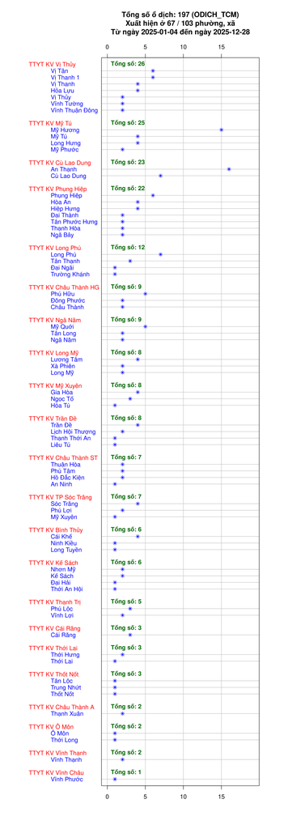

# 5 **TỔNG SỐ** **Ổ DỊCH** **THEO THÁNG**

| TTYTKV | Phường, xã mới | Tháng | Tổng số ca |
| --- | --- | --- | --- |
| TTYT KV Kế Sách | Kế Sách | 1 | 2 |
| TTYT KV Châu Thành ST | Phú Tâm | 1 | 1 |
| TTYT KV Cù Lao Dung | An Thạnh | 2 | 2 |
| TTYT KV Cù Lao Dung | Cù Lao Dung | 2 | 2 |
| TTYT KV Cù Lao Dung | An Thạnh | 3 | 1 |
| TTYT KV Long Mỹ | Lương Tâm | 3 | 2 |
| TTYT KV Ô Môn | Ô Môn | 3 | 1 |
| TTYT KV TP Sóc Trăng | Sóc Trăng | 3 | 1 |
| TTYT KV Vĩnh Thạnh | Vĩnh Thạnh | 3 | 1 |
| TTYT KV Cù Lao Dung | An Thạnh | 4 | 2 |

[output cut: 114 more lines]

# 6 **ĐỒ THỊ TỔNG SỐ** **Ổ DỊCH** **THEO THỜI GIAN**

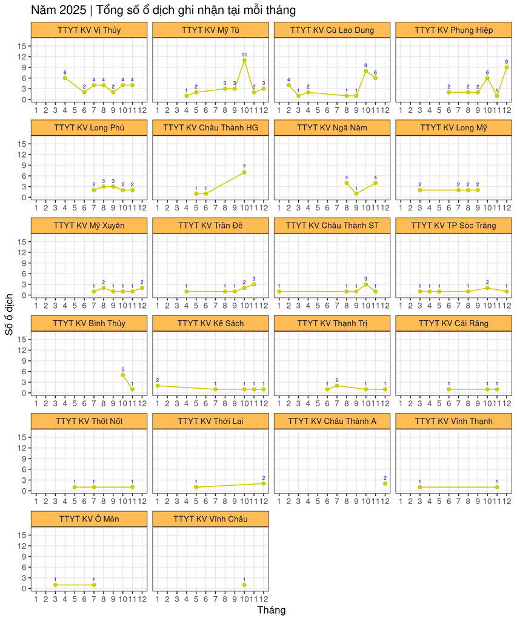

[figure not shown]

# 7 **TỔNG SỐ** **Ổ DỊCH** **THEO TUẦN**

| TTYTKV | PHUONG_XA_MOI | WEEK | COUNT |
| --- | --- | --- | --- |
| TTYT KV Châu Thành ST | Phú Tâm | 1 | 1 |
| TTYT KV Kế Sách | Kế Sách | 2 | 1 |
| TTYT KV Kế Sách | Kế Sách | 4 | 1 |
| TTYT KV Cù Lao Dung | An Thạnh | 7 | 1 |
| TTYT KV Cù Lao Dung | An Thạnh | 9 | 1 |
| TTYT KV Cù Lao Dung | Cù Lao Dung | 9 | 2 |
| TTYT KV Ô Môn | Ô Môn | 9 | 1 |
| TTYT KV Long Mỹ | Lương Tâm | 11 | 2 |
| TTYT KV TP Sóc Trăng | Sóc Trăng | 11 | 1 |
| TTYT KV Vĩnh Thạnh | Vĩnh Thạnh | 12 | 1 |

[output cut: 141 more lines]

# 8 **ĐỒ THỊ THEO NGÀY**

## 8.1 TTYT KV Châu Thành ST

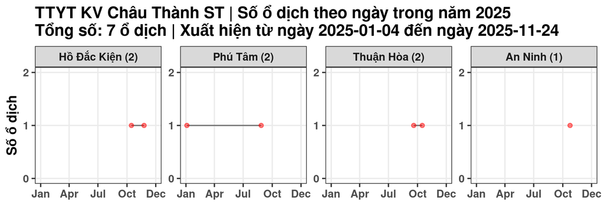

## 8.2 TTYT KV Kế Sách

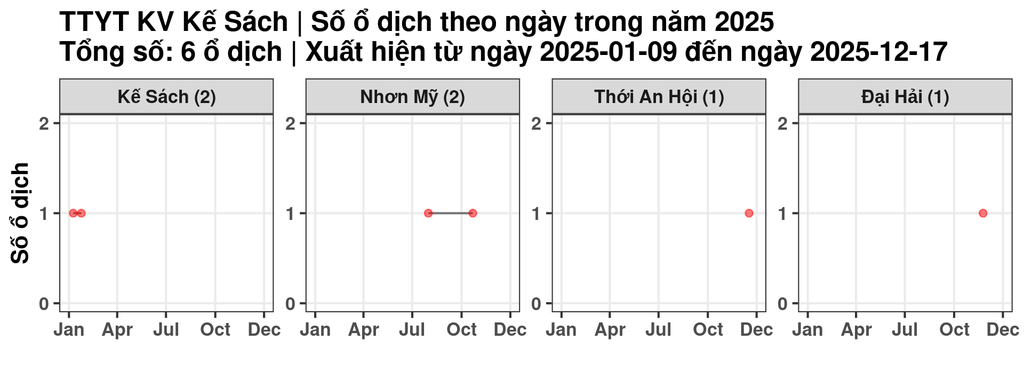

## 8.3 TTYT KV Cù Lao Dung

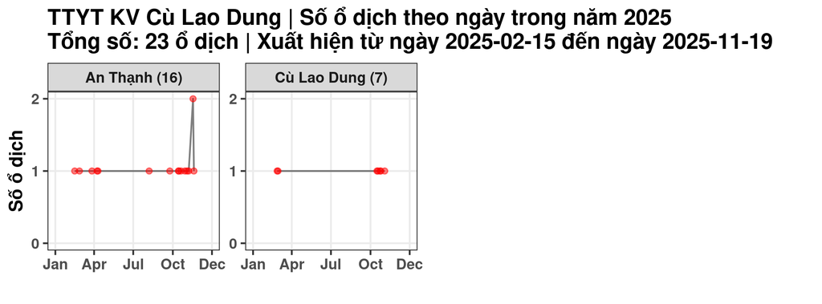

## 8.4 TTYT KV Ô Môn

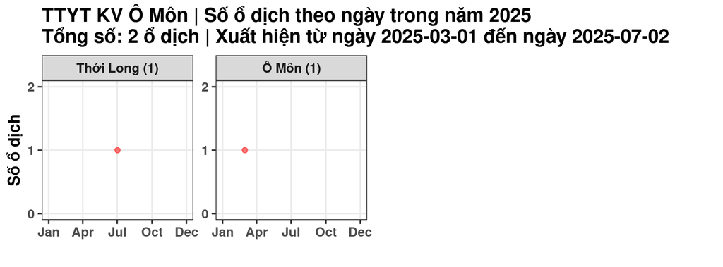

## 8.5 TTYT KV TP Sóc Trăng

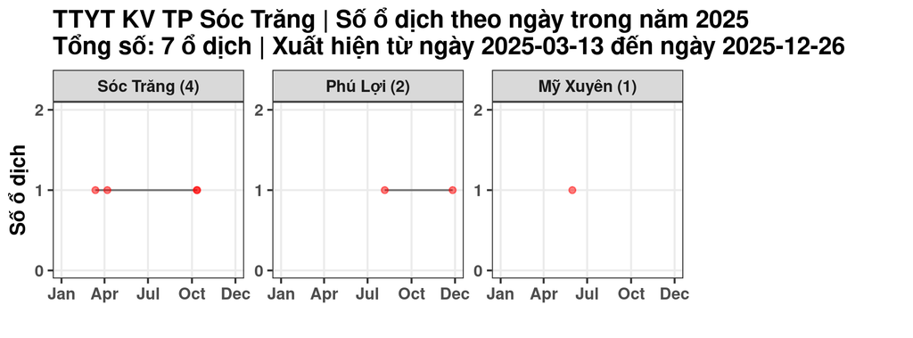

## 8.6 TTYT KV Long Mỹ

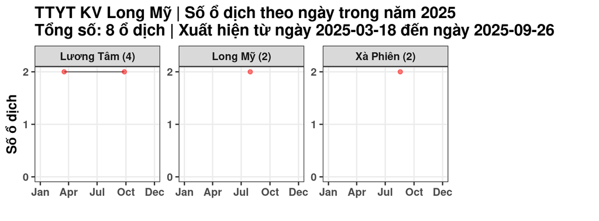

## 8.7 TTYT KV Vĩnh Thạnh

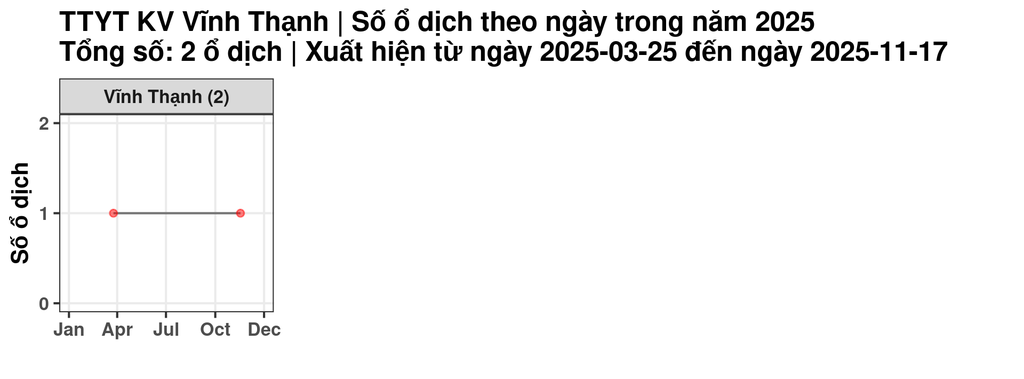

## 8.8 TTYT KV Mỹ Tú

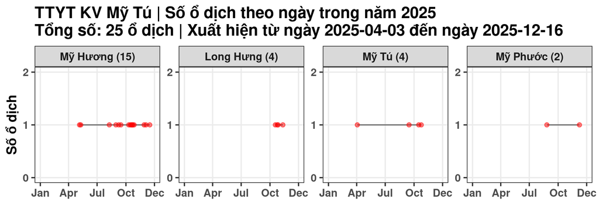

## 8.9 TTYT KV Vị Thủy

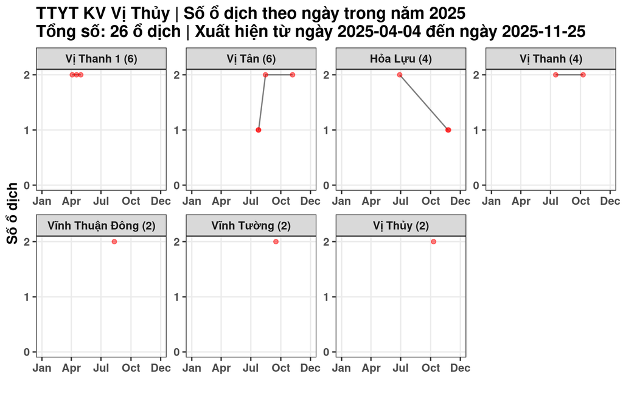

## 8.10 TTYT KV Trần Đề

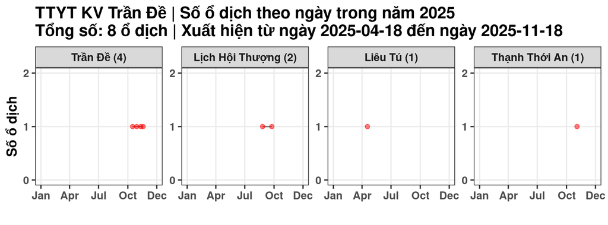

## 8.11 TTYT KV Thới Lai

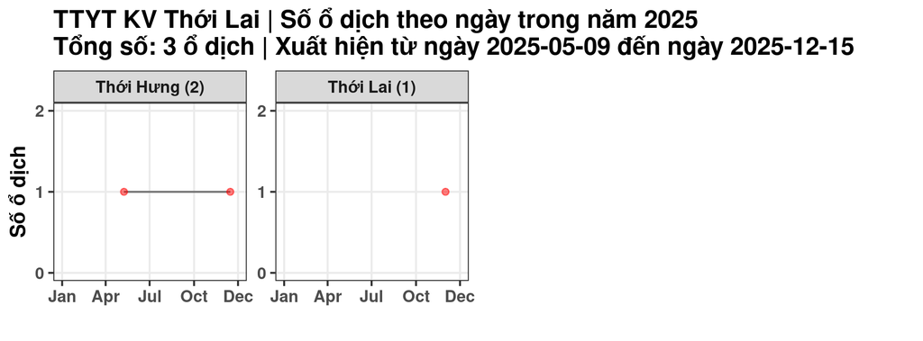

## 8.12 TTYT KV Thốt Nốt

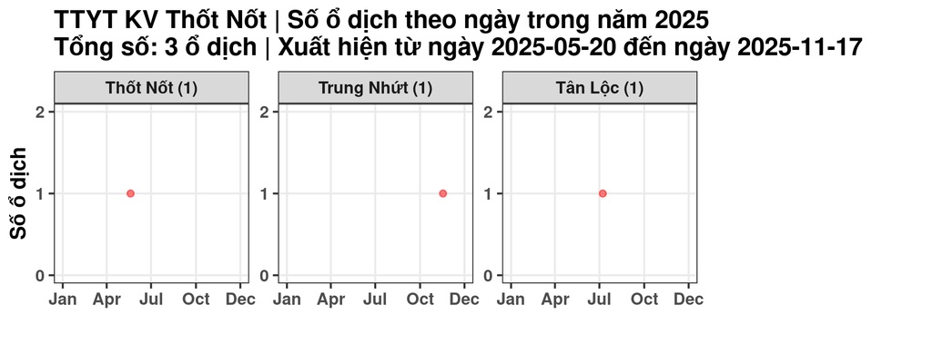

## 8.13 TTYT KV Châu Thành HG

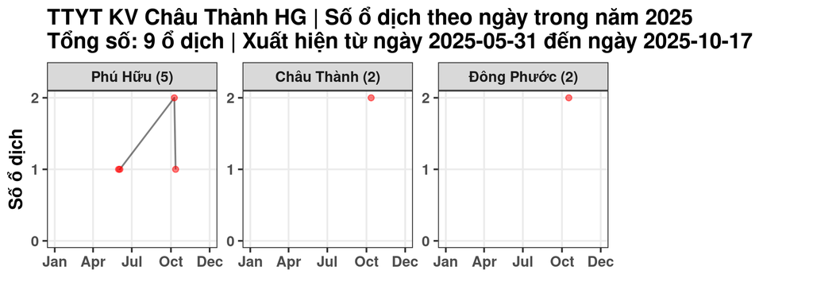

## 8.14 TTYT KV Phụng Hiệp

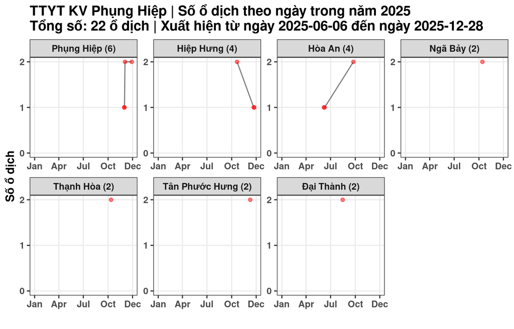

## 8.15 TTYT KV Thạnh Trị

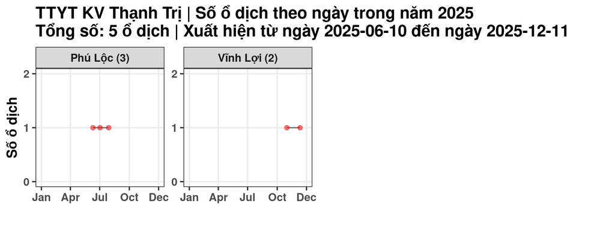

## 8.16 TTYT KV Cái Răng

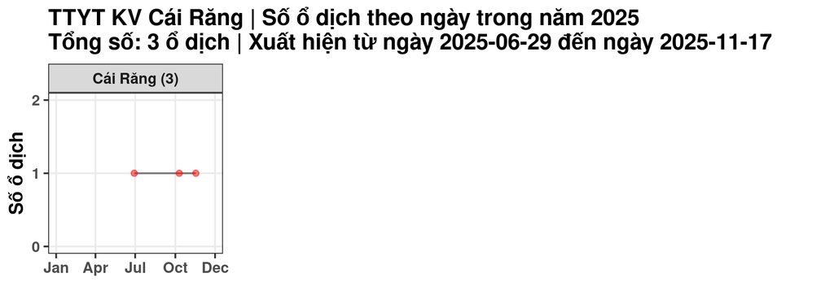

## 8.17 TTYT KV Long Phú

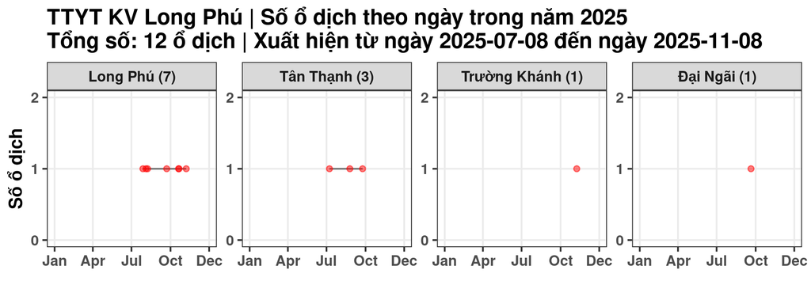

## 8.18 TTYT KV Mỹ Xuyên

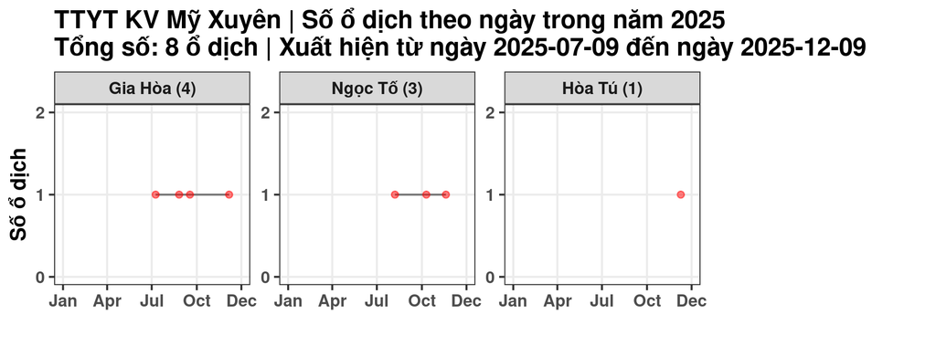

## 8.19 TTYT KV Ngã Năm

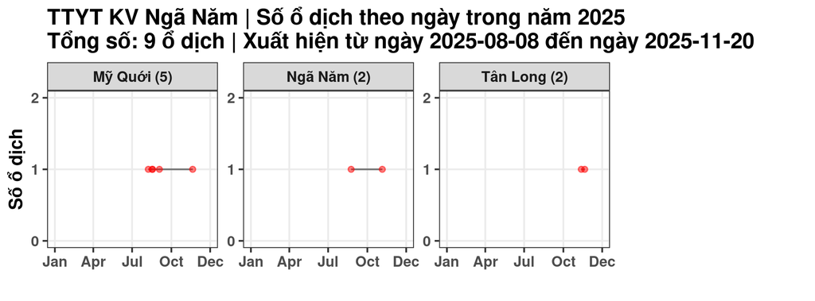

## 8.20 TTYT KV Bình Thủy

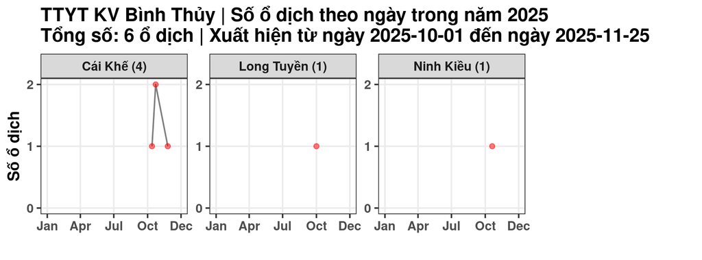

## 8.21 TTYT KV Vĩnh Châu

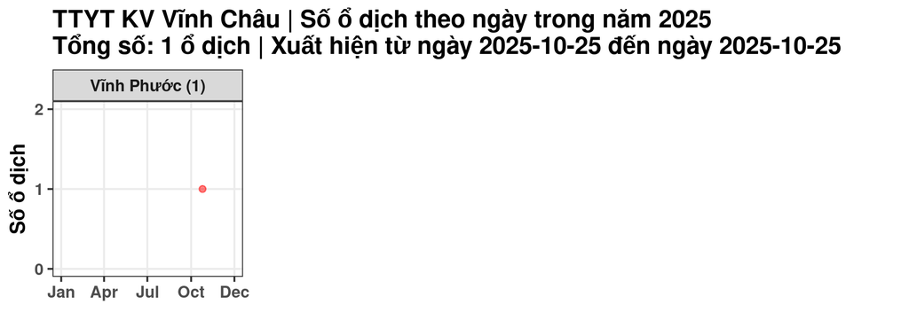

## 8.22 TTYT KV Châu Thành A

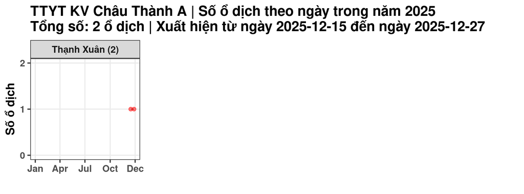

# 9 **ĐỒ THỊ THEO TUẦN**

## 9.1 TTYT KV Châu Thành ST

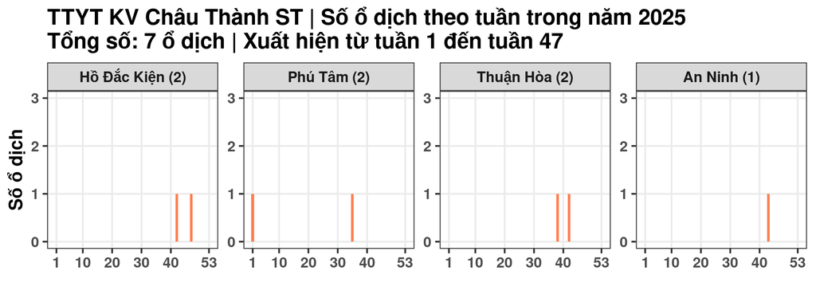

## 9.2 TTYT KV Kế Sách

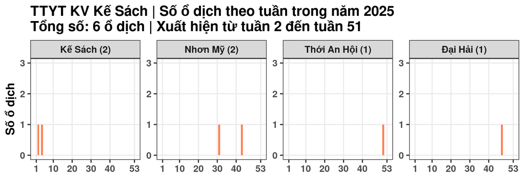

## 9.3 TTYT KV Cù Lao Dung

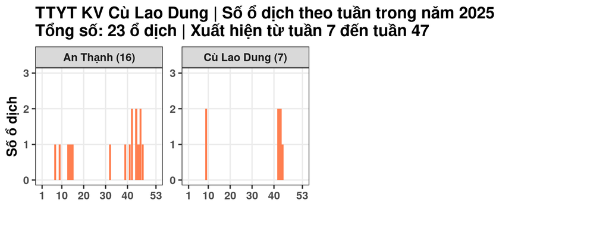

## 9.4 TTYT KV Ô Môn

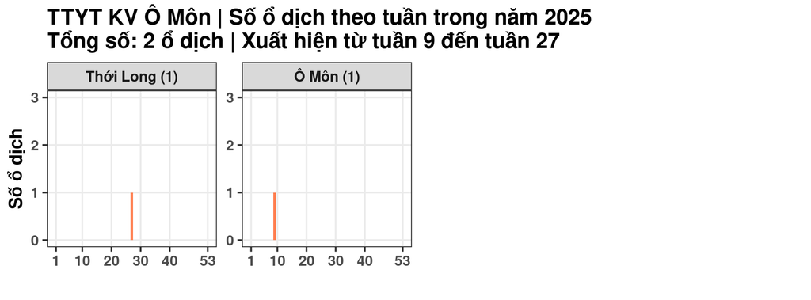